# My SpotifyR report

Author

Elena Leow Alegre

# You are the Music in Me: a History of my Music Taste Throughout the Years

## Music and Personality

Another question I want to ask is “how basic am I?”, as I consider my music tastes to be quite average, and definitely influenced by recency bias. Therefore, this study will test how basic I am by seeing what proportion of songs were on the Top 100 billboard that year.

## Top Songs

#### 2020

[figure not shown]

[Don’t Start Now - Dua Lipa](https://www.youtube.com/watch?v=oygrmJFKYZY&list=RDoygrmJFKYZY&start_radio=1)

### 2021

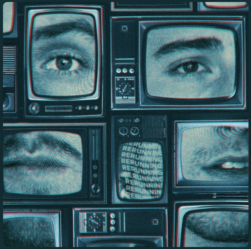

[Ain’t Got Much To Go - Fly By Midnight](https://www.youtube.com/watch?v=pDezl0GXewo&list=RDpDezl0GXewo&start_radio=1)

### 2022

[figure not shown]

[Forget You - Cee Lo Green](https://www.youtube.com/watch?v=bKxodgpyGec)

### 2023

[figure not shown]

[Nonsense - Sabrina Carpenter](https://www.youtube.com/watch?v=YcSP1ZUf1eQ)

### 2024

[figure not shown]

[Espresso - Sabrina Carpenter](https://www.youtube.com/watch?v=eVli-tstM5E)

### 2025

[figure not shown]

[So Far Gone - ROLE MODEL ft. Lizzy McAlpine](https://www.youtube.com/watch?v=E5XY0nIr-8k)

## Data Preparation

I created my own dataset using my Top 10 songs from the year 2020-2025, accessing the information using professor Joy’s web server. I also included whether the songs had been on the Top 100 Billboard to see how mainstream the music taste was to analyse how basic my music taste is further on. Because I made the dataset myself I knew there were no live songs included or duplicates either, which made the process easier as well.

Thus all I had to do was upload my libraries and had R read my excel dataset.

```r
library(dplyr)
library(ggplot2)
library(knitr)

df <- read.csv("music-analysis.csv")
```

## Data Frame

To make sure everything was alright I check the data frame down below.

```r
df |> dplyr :: slice_sample(n=5)|> knitr::kable(digits = 2)
```

| Year | Song | Artist | Acousticness | Danceability | Energy | Instrumentalness | Liveness | Loudness | Speechiness | Tempo | Valence | Billboard |
| --- | --- | --- | --- | --- | --- | --- | --- | --- | --- | --- | --- | --- |
| 2025 | Better Than This | Lizzy McAlpine | 0.88 | 0.58 | 0.17 | 0 | 0.08 | -11.49 | 0.03 | 85.26 | 0.40 | N |
| 2021 | good 4 u | Olivia Rodrigo | 0.34 | 0.56 | 0.66 | 0 | 0.08 | -5.04 | 0.15 | 166.93 | 0.69 | Y |
| 2023 | Look At Us Now (Honeycomb) | Daisy Jones & The Six | 0.01 | 0.32 | 0.76 | 0 | 0.08 | -6.14 | 0.05 | 141.28 | 0.47 | N |
| 2020 | Painkiller | Ruel | 0.09 | 0.68 | 0.42 | 0 | 0.22 | -6.51 | 0.05 | 128.62 | 0.47 | N |
| 2020 | Don’t Start Now | Dua Lipa | 0.01 | 0.79 | 0.79 | 0 | 0.10 | -4.52 | 0.08 | 123.95 | 0.68 | Y |

## Data Analysis

First, to see whether the songs i listened to were happy, sad, angry, or peaceful, I plotted my songs based on Valence and Energy.

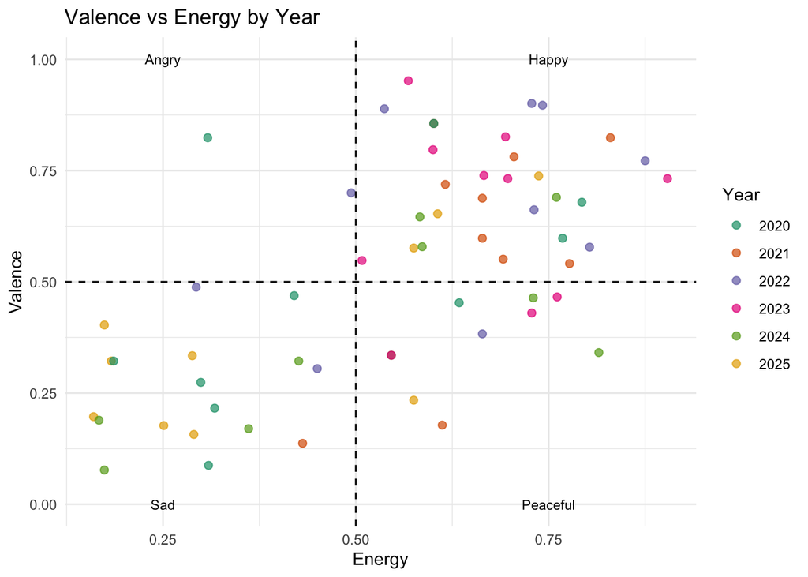

```r
ggplot(df, aes(x = Energy, y = Valence, color = factor(Year))) +
  geom_point(alpha = 0.7, size = 2) +
  scale_color_brewer(palette = "Dark2") +
    geom_vline(xintercept = 0.5, linetype = "dashed") +
  geom_hline(yintercept = 0.5, linetype = "dashed") +
  annotate("text", x = 0.25, y = 1, label = "Angry", size = 3) +
  annotate("text", x = 0.25, y = 0, label = "Sad", size = 3) +
  annotate("text", x = 0.75, y = 1, label = "Happy", size = 3) +
  annotate("text", x = 0.75, y = 0, label = "Peaceful", size = 3) +
  labs(title = "Valence vs Energy by Year",
       x = "Energy",
       y = "Valence",
       color = "Year") +
  theme_minimal()
```

But what about my moods throughout the years?

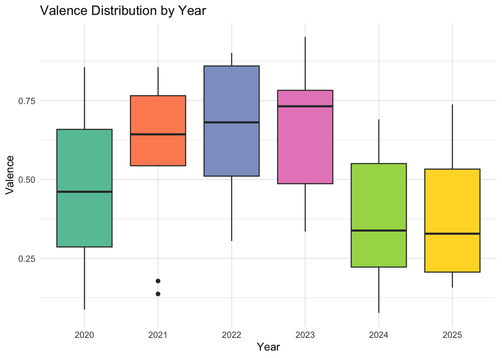

```r
library(ggplot2)
library(dplyr)
ggplot(df, aes(x = factor(Year), y = Valence, fill = factor(Year))) +
  geom_boxplot() +
  scale_fill_brewer(palette = "Set2") +
  labs(title = "Valence Distribution by Year",
       x = "Year",
       y = "Valence") +
  theme_minimal() +
  theme(legend.position = "none")
```

We can see a rise and then fall in the medians of valence per year. The variation of valence however was quite equal throughout the years with the exception of 2021. But what happened after 2023? Why did my music taste become more negative? Oh maybe it’s because I j joined LUC…coincidence or correlated? In my opion I think other factors such as my increased listening to “study music” and taste in calmer music grew. Doesn’t mean I am less happy though.

### 3 Most Positive Songs

What were my three most positive songs? When did I listen to them?

```r
library(dplyr)

df |>
  slice_max(Valence, n=3) |>
  dplyr::select(Song, Artist, Year, Valence) |>
  knitr::kable(digits = 2)
```

| Song | Artist | Year | Valence |
| --- | --- | --- | --- |
| Sir Duke | Stevie Wonder | 2023 | 0.95 |
| Late Night Talking | Harry Styles | 2022 | 0.90 |
| Koala | Grady | 2022 | 0.90 |

### 3 Least Positive Songs

and least?

```r
library(dplyr)

df |>
  slice_min(Valence, n=3) |>
  dplyr::select(Song, Artist, Year, Valence) |>
  knitr::kable(digits = 2)
```

| Song | Artist | Year | Valence |
| --- | --- | --- | --- |
| I Only Have Eyes for You | Art Garfunkel | 2024 | 0.08 |
| my future | Billie Eilish | 2020 | 0.09 |
| drivers license | Olivia Rodrigo | 2021 | 0.14 |

I think the algorithm is a little wrong in this instance, as “Only have Eyes for you” is a love song. Although it is a very slow song, its lyrics are positive.

[video not shown]

Just Dance?

As a bit of a dancer myself, I think a lot of songs I listen to are based off danceability. Some of my top 10 songs each year are there because I have had to dance them for a performance of sorts. So are they danceable?

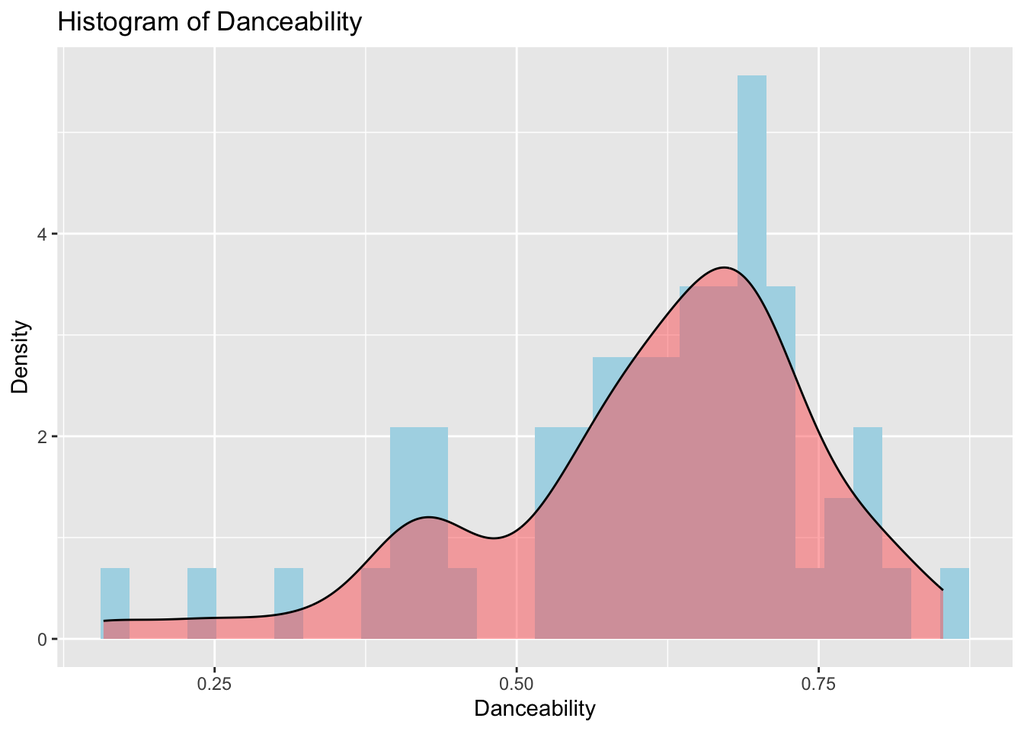

```r
ggplot(df, aes(x=Danceability)) +
geom_histogram(aes(y=..density..), fill="lightblue") +
geom_density(fill="#FF6666", alpha = 0.5) +
labs(title="Histogram of Danceability", x="Danceability", y="Density")
```

The histogram is bimodal with two peaks. The biggest peak is at around 0.7 showing that the majority of my music is danceable but there is also a smaller peak at around 0.4 which suggests a smaller portion of my music taste is less danceable. This does confim though that most of my music reflects my passion of dancing.

### What about across years?…

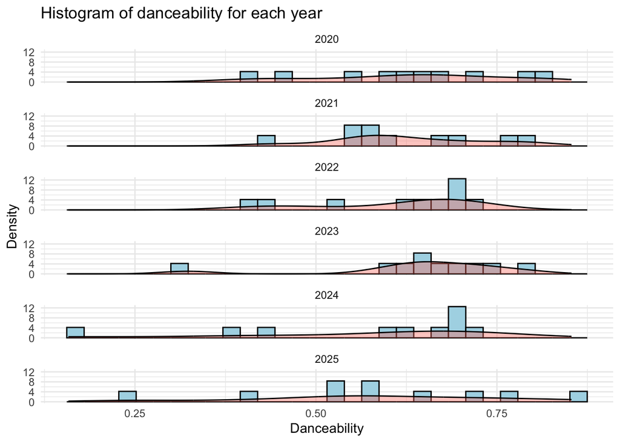

```r
library(ggplot2)
ggplot(df, aes(x = Danceability)) +
  geom_histogram(aes(y = after_stat(density)), bins = 30,
                 fill = "lightblue", color = "black") +
  geom_density(fill = "salmon", alpha = 0.4) +
  facet_wrap(~ Year, ncol = 1) +
  labs(title = "Histogram of danceability for each year",
       x = "Danceability", y = "Density") +
  theme_minimal() +
  theme(panel.spacing = unit(0.5, "lines"))
```

The histograms over the years gain show that my music mainly peaks over 0.5 of danceability especially between 2022-2024. It seems that 2025 has the most sporadic result with the highest density at just over 0.5 but with no noticeable peak. There is also a few bars over the year around 0.4 which explains the bimodal peak seen in the previous diagram.

### 3 Most Danceable Songs

```r
library(dplyr)

df |>
  slice_max(Danceability, n=3) |>
  dplyr::select(Song, Artist, Year, Danceability) |>
  knitr::kable(digits = 2)
```

| Song | Artist | Year | Danceability |
| --- | --- | --- | --- |
| It Wasn’t Me | Shaggy | 2025 | 0.85 |
| Backyard Boy | Claire Rosinfrankz | 2020 | 0.82 |
| flowerbeds | Sfven | 2021 | 0.80 |

[figure not shown]

[video not shown]

### 3 Least Danceable Songs

```r
library(dplyr)

df |>
  slice_min(Danceability, n=3) |>
  dplyr::select(Song, Artist, Year, Danceability) |>
  knitr::kable(digits = 2)
```

| Song | Artist | Year | Danceability |
| --- | --- | --- | --- |
| I Only Have Eyes for You | Art Garfunkel | 2024 | 0.16 |
| Soccer Practice | Lizzy McAlpine | 2025 | 0.24 |
| Look At Us Now (Honeycomb) | Daisy Jones & The Six | 2023 | 0.32 |

## Basically Basic?

Am I basic? I personally feel like my music taste is - not that that is necessarily a bad thing to be honest. But I wanted to check this statistically, out of all the songs in my Top 10 over the years, how many of them have been on the Top 100 Billboard?

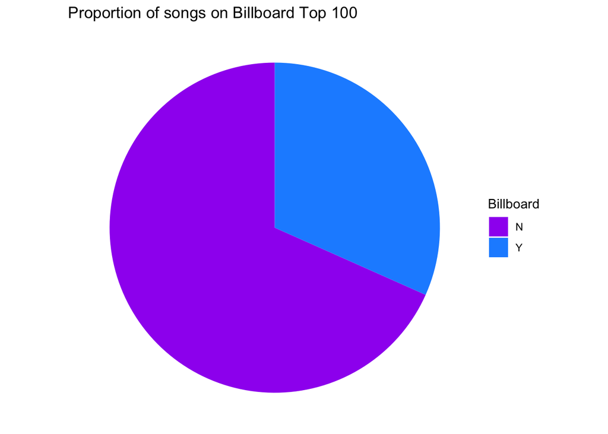

```r
library(ggplot2)

# Count Y/N values in your column
billboard_table <- table(df$Billboard)

# Convert to data frame and rename columns
df_billboard <- as.data.frame(billboard_table)
colnames(df_billboard) <- c("Billboard", "Freq")  # important step

# Create pie chart
ggplot(df_billboard, aes(x = "", y = Freq, fill = Billboard)) +
  geom_col() +
  coord_polar(theta = "y") +
  scale_fill_manual(values = c("purple", "dodgerblue")) +
  theme_void() +
  labs(title = "Proportion of songs on Billboard Top 100")
```

### Have I gotten more basic over the years?

```r
chisq.test(table(df$Year, df$Billboard))
```

```
    Pearson's Chi-squared test

data:  table(df$Year, df$Billboard)
X-squared = 6.8549, df = 5, p-value = 0.2317
```

A chi-square test found no significant association between year and Billboard chart presence (χ²= 6.85, df = 5, p = 0.23), though the small sample size limits the reliability of this finding.

[output not shown]